# Reproducible report: Incidence-severity relationships in unmanaged and fungicide-protected wheat head blast epidemics in Brazil

Created: 2021-10-06 Last update: 2022-03-22

# The report

This report aims to demonstrate, using R programming, all the steps of the analysis of the *I-S* relationship for the wheat blast pathosystem, from data preparation to presentation of the results, in a way that anyone who is interested in the area and wants to reproduce the analysis can do this. The data, codes, pre-print version of the article and supplementary materials were also made available at this GitHub repository. The report is the html output of an R markdown file prepared whit R Studio IDE for R. The plots were prepared using the `ggplot2` package.

# Packages

First we need to load the R packages.

```r
library(tidyverse)
library(readxl)
library(ggplot2)
library(cowplot)
library(ggthemes)
library(car)
library(report)
library(patchwork)
```

# Importing data

```
The data was organized in the long or lard format where each column is a variable and each observation is placed in a row. The code to import data is:
```

```r
data_epamig <- read_excel("Data/data_epamig.xlsx")
general_slim_data <- read_excel("Data/generalslim_data.xlsx")
```

Here we create a simple point plot using the `ggplot2` package to quickly observe the average distribution of the data from both data sets

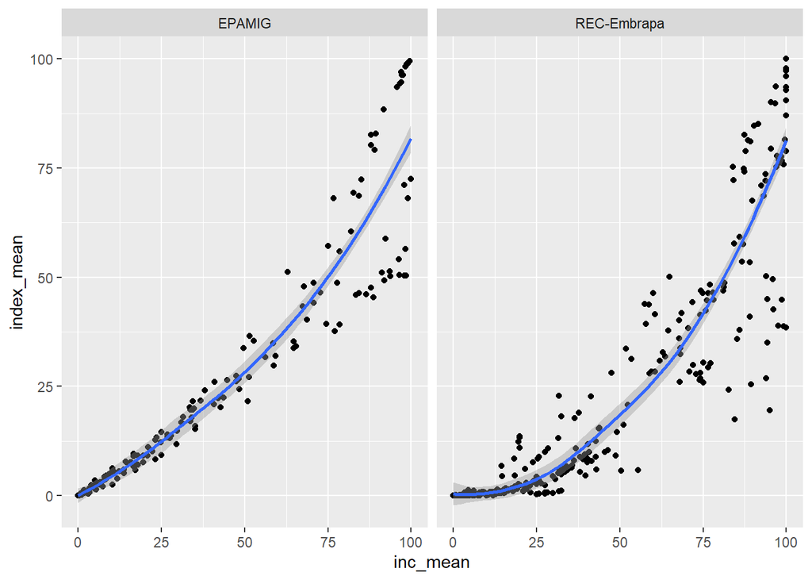

```r
general_slim_data %>%
  ggplot(aes(inc_mean, index_mean))+
  geom_point()+
  geom_smooth()+
  facet_wrap( ~ source)
```

# Summary and data transformation

```r
epamig_data <- data_epamig %>%
  mutate(idx = (inc*dhs)/100) %>%
  relocate(idx, .before = tgw) %>%
  dplyr::filter(idx > 0) %>%
  dplyr::filter(!cultivar == "SINTONIA") %>%
  mutate(clog_inc = log(-log(1 - (inc/100))),
         clog_idx = log(-log(1 - (idx/100))))




rede_data <- general_slim_data %>%
  dplyr::filter(source == "REC-Embrapa") %>%
  dplyr::filter(index_mean > 0) %>%
  mutate(inc_rede = case_when(inc_mean == 100 ~ 99,
                              inc_mean <= 99.9 ~ inc_mean),
         idx_rede = case_when(index_mean == 100 ~ 99,
                              index_mean <= 99.9 ~ index_mean)) %>%
  mutate(clog_inc = log(-log(1 - (inc_rede/100))),
         clog_idx = log(-log(1 - (idx_rede/100))))
```

# Interactions

In this section, we are testing for the EPAMIG data if there is a significant influence of the years and cultivar in the incidence severity relationship. For this test, year and cultivar were used as moderator variables in ordinal linear regression, the significance of the effect was tested using an ANOVA test.

```r
aa <- lm(clog_idx ~ clog_inc*year, data = epamig_data)
bb <- lm(clog_idx ~ clog_inc*cultivar, data = epamig_data)

anova(aa)
```

```
## Analysis of Variance Table
##
## Response: clog_idx
##                Df  Sum Sq Mean Sq   F value    Pr(>F)
## clog_inc        1 2532.59 2532.59 16199.537 < 2.2e-16 ***
## year            1    3.92    3.92    25.083 6.958e-07 ***
## clog_inc:year   1   17.60   17.60   112.574 < 2.2e-16 ***
## Residuals     700  109.44    0.16
## ---
## Signif. codes:  0 '***' 0.001 '**' 0.01 '*' 0.05 '.' 0.1 ' ' 1
```

```r
anova(bb)
```

```
## Analysis of Variance Table
##
## Response: clog_idx
##                    Df  Sum Sq Mean Sq    F value  Pr(>F)
## clog_inc            1 2532.59 2532.59 13681.6301 < 2e-16 ***
## cultivar            2    0.53    0.27     1.4370 0.23834
## clog_inc:cultivar   2    1.22    0.61     3.2928 0.03773 *
## Residuals         698  129.21    0.19
## ---
## Signif. codes:  0 '***' 0.001 '**' 0.01 '*' 0.05 '.' 0.1 ' ' 1
```

# Separating the EPAMIG data

Due to the significant influence of the year as a moderator variable, we separated the EPAMIG data into the 7 years of experiments, for the following analysis.

```r
data_2013 <- epamig_data %>%
  filter(year == 2013)

data_2014 <- epamig_data %>%
  filter(year == 2014)

data_2015 <- epamig_data %>%
  filter(year == 2015)

data_2016 <- epamig_data %>%
  filter(year == 2016)

data_2017 <- epamig_data %>%
  filter(year == 2017)

data_2018 <- epamig_data %>%
  filter(year == 2018)

data_2019 <- epamig_data %>%
  filter(year == 2019)
```

# Linear Regression model

In this section we fitted a, ordinary linear regression model to UFTs data, to the pooled EPAMIG data and to data from each year of the EPAMIG data. In additional, we summarise the parameters and coefficients of each model, and using the `linearHypothesis` function of the `car` package we verify if the slopes are significantly different of 1.

## UFTs data

```r
lm_pooled_rede <- lm(clog_idx ~ clog_inc, data = rede_data)
summary(lm_pooled_rede)
```

```
##
## Call:
## lm(formula = clog_idx ~ clog_inc, data = rede_data)
##
## Residuals:
##     Min      1Q  Median      3Q     Max
## -3.9553 -0.3791  0.0950  0.5284  2.8442
##
## Coefficients:
##             Estimate Std. Error t value Pr(>|t|)
## (Intercept) -1.46733    0.06583  -22.29   <2e-16 ***
## clog_inc     1.61443    0.03370   47.90   <2e-16 ***
## ---
## Signif. codes:  0 '***' 0.001 '**' 0.01 '*' 0.05 '.' 0.1 ' ' 1
##
## Residual standard error: 0.9993 on 317 degrees of freedom
## Multiple R-squared:  0.8786, Adjusted R-squared:  0.8782
## F-statistic:  2294 on 1 and 317 DF,  p-value: < 2.2e-16
```

```r
report(lm_pooled_rede)
```

```
## 'interpret_d()' is now deprecated. Please use 'interpret_cohens_d()'.
## 'interpret_d()' is now deprecated. Please use 'interpret_cohens_d()'.
```

```
## We fitted a linear model (estimated using OLS) to predict clog_idx with clog_inc (formula: clog_idx ~ clog_inc). The model explains a statistically significant and substantial proportion of variance (R2 = 0.88, F(1, 317) = 2294.34, p < .001, adj. R2 = 0.88). The model's intercept, corresponding t…
##
##   - The effect of clog_inc is statistically significant and positive (beta = 1.61, 95% CI [1.55, 1.68], t(317) = 47.90, p < .001; Std. beta = 0.94, 95% CI [0.90, 0.98])
##
## Standardized parameters were obtained by fitting the model on a standardized version of the dataset.
```

```r
anova(lm_pooled_rede)
```

```
## Analysis of Variance Table
##
## Response: clog_idx
##            Df  Sum Sq Mean Sq F value    Pr(>F)
## clog_inc    1 2291.10  2291.1  2294.3 < 2.2e-16 ***
## Residuals 317  316.55     1.0
## ---
## Signif. codes:  0 '***' 0.001 '**' 0.01 '*' 0.05 '.' 0.1 ' ' 1
```

```r
car::linearHypothesis(lm_pooled_rede, "clog_inc = 1")
```

```
## Linear hypothesis test
##
## Hypothesis:
## clog_inc = 1
##
## Model 1: restricted model
## Model 2: clog_idx ~ clog_inc
##
##   Res.Df    RSS Df Sum of Sq      F    Pr(>F)
## 1    318 648.41
## 2    317 316.55  1    331.86 332.33 < 2.2e-16 ***
## ---
## Signif. codes:  0 '***' 0.001 '**' 0.01 '*' 0.05 '.' 0.1 ' ' 1
```

## EPAMIG pooled data

```r
lm_pooled <- lm(clog_idx ~ clog_inc, data = epamig_data)
summary(lm_pooled)
```

```
##
## Call:
## lm(formula = clog_idx ~ clog_inc, data = epamig_data)
##
## Residuals:
##      Min       1Q   Median       3Q      Max
## -1.59928 -0.18616  0.05177  0.26326  0.93987
##
## Coefficients:
##              Estimate Std. Error t value Pr(>|t|)
## (Intercept) -0.821799   0.020858   -39.4   <2e-16 ***
## clog_inc     1.025668   0.008803   116.5   <2e-16 ***
## ---
## Signif. codes:  0 '***' 0.001 '**' 0.01 '*' 0.05 '.' 0.1 ' ' 1
##
## Residual standard error: 0.4319 on 702 degrees of freedom
## Multiple R-squared:  0.9508, Adjusted R-squared:  0.9508
## F-statistic: 1.358e+04 on 1 and 702 DF,  p-value: < 2.2e-16
```

```r
report(lm_pooled)
```

```
## 'interpret_d()' is now deprecated. Please use 'interpret_cohens_d()'.
## 'interpret_d()' is now deprecated. Please use 'interpret_cohens_d()'.
```

```
## We fitted a linear model (estimated using OLS) to predict clog_idx with clog_inc (formula: clog_idx ~ clog_inc). The model explains a statistically significant and substantial proportion of variance (R2 = 0.95, F(1, 702) = 13576.05, p < .001, adj. R2 = 0.95). The model's intercept, corresponding …
##
##   - The effect of clog_inc is statistically significant and positive (beta = 1.03, 95% CI [1.01, 1.04], t(702) = 116.52, p < .001; Std. beta = 0.98, 95% CI [0.96, 0.99])
##
## Standardized parameters were obtained by fitting the model on a standardized version of the dataset.
```

```r
anova(lm_pooled)
```

```
## Analysis of Variance Table
##
## Response: clog_idx
##            Df  Sum Sq Mean Sq F value    Pr(>F)
## clog_inc    1 2532.59 2532.59   13576 < 2.2e-16 ***
## Residuals 702  130.96    0.19
## ---
## Signif. codes:  0 '***' 0.001 '**' 0.01 '*' 0.05 '.' 0.1 ' ' 1
```

```r
car::linearHypothesis(lm_pooled, "clog_inc = 1")
```

```
## Linear hypothesis test
##
## Hypothesis:
## clog_inc = 1
##
## Model 1: restricted model
## Model 2: clog_idx ~ clog_inc
##
##   Res.Df    RSS Df Sum of Sq      F  Pr(>F)
## 1    703 132.54
## 2    702 130.96  1    1.5861 8.5022 0.00366 **
## ---
## Signif. codes:  0 '***' 0.001 '**' 0.01 '*' 0.05 '.' 0.1 ' ' 1
```

## 2013

```r
lm_2013 <- lm(clog_idx ~ clog_inc, data = data_2013)
summary(lm_2013)
```

```
##
## Call:
## lm(formula = clog_idx ~ clog_inc, data = data_2013)
##
## Residuals:
##      Min       1Q   Median       3Q      Max
## -1.45212 -0.15534 -0.01292  0.18521  0.85499
##
## Coefficients:
##             Estimate Std. Error t value Pr(>|t|)
## (Intercept) -0.63826    0.04898  -13.03   <2e-16 ***
## clog_inc     1.04711    0.02559   40.92   <2e-16 ***
## ---
## Signif. codes:  0 '***' 0.001 '**' 0.01 '*' 0.05 '.' 0.1 ' ' 1
##
## Residual standard error: 0.3285 on 90 degrees of freedom
## Multiple R-squared:  0.949,  Adjusted R-squared:  0.9484
## F-statistic:  1675 on 1 and 90 DF,  p-value: < 2.2e-16
```

```r
report(lm_2013)
```

```
## 'interpret_d()' is now deprecated. Please use 'interpret_cohens_d()'.
## 'interpret_d()' is now deprecated. Please use 'interpret_cohens_d()'.
```

```
## We fitted a linear model (estimated using OLS) to predict clog_idx with clog_inc (formula: clog_idx ~ clog_inc). The model explains a statistically significant and substantial proportion of variance (R2 = 0.95, F(1, 90) = 1674.70, p < .001, adj. R2 = 0.95). The model's intercept, corresponding to…
##
##   - The effect of clog_inc is statistically significant and positive (beta = 1.05, 95% CI [1.00, 1.10], t(90) = 40.92, p < .001; Std. beta = 0.97, 95% CI [0.93, 1.02])
##
## Standardized parameters were obtained by fitting the model on a standardized version of the dataset.
```

```r
anova(lm_2013)
```

```
## Analysis of Variance Table
##
## Response: clog_idx
##           Df  Sum Sq Mean Sq F value    Pr(>F)
## clog_inc   1 180.700 180.700  1674.7 < 2.2e-16 ***
## Residuals 90   9.711   0.108
## ---
## Signif. codes:  0 '***' 0.001 '**' 0.01 '*' 0.05 '.' 0.1 ' ' 1
```

```r
car::linearHypothesis(lm_2013, "clog_inc = 1")
```

```
## Linear hypothesis test
##
## Hypothesis:
## clog_inc = 1
##
## Model 1: restricted model
## Model 2: clog_idx ~ clog_inc
##
##   Res.Df    RSS Df Sum of Sq      F  Pr(>F)
## 1     91 10.077
## 2     90  9.711  1   0.36581 3.3903 0.06888 .
## ---
## Signif. codes:  0 '***' 0.001 '**' 0.01 '*' 0.05 '.' 0.1 ' ' 1
```

## 2014

```r
lm_2014 <- lm(clog_idx ~ clog_inc, data = data_2014)
summary(lm_2014)
```

```
##
## Call:
## lm(formula = clog_idx ~ clog_inc, data = data_2014)
##
## Residuals:
##      Min       1Q   Median       3Q      Max
## -1.56529 -0.10812  0.06962  0.18572  0.63595
##
## Coefficients:
##             Estimate Std. Error t value Pr(>|t|)
## (Intercept) -1.05514    0.03772  -27.97   <2e-16 ***
## clog_inc     0.93189    0.01385   67.30   <2e-16 ***
## ---
## Signif. codes:  0 '***' 0.001 '**' 0.01 '*' 0.05 '.' 0.1 ' ' 1
##
## Residual standard error: 0.305 on 123 degrees of freedom
## Multiple R-squared:  0.9736, Adjusted R-squared:  0.9733
## F-statistic:  4529 on 1 and 123 DF,  p-value: < 2.2e-16
```

```r
anova(lm_2014)
```

```
## Analysis of Variance Table
##
## Response: clog_idx
##            Df Sum Sq Mean Sq F value    Pr(>F)
## clog_inc    1 421.22  421.22  4528.9 < 2.2e-16 ***
## Residuals 123  11.44    0.09
## ---
## Signif. codes:  0 '***' 0.001 '**' 0.01 '*' 0.05 '.' 0.1 ' ' 1
```

```r
report(lm_2014)
```

```
## 'interpret_d()' is now deprecated. Please use 'interpret_cohens_d()'.
## 'interpret_d()' is now deprecated. Please use 'interpret_cohens_d()'.
```

```
## We fitted a linear model (estimated using OLS) to predict clog_idx with clog_inc (formula: clog_idx ~ clog_inc). The model explains a statistically significant and substantial proportion of variance (R2 = 0.97, F(1, 123) = 4528.86, p < .001, adj. R2 = 0.97). The model's intercept, corresponding t…
##
##   - The effect of clog_inc is statistically significant and positive (beta = 0.93, 95% CI [0.90, 0.96], t(123) = 67.30, p < .001; Std. beta = 0.99, 95% CI [0.96, 1.02])
##
## Standardized parameters were obtained by fitting the model on a standardized version of the dataset.
```

```r
car::linearHypothesis(lm_2014, "clog_inc = 1")
```

```
## Linear hypothesis test
##
## Hypothesis:
## clog_inc = 1
##
## Model 1: restricted model
## Model 2: clog_idx ~ clog_inc
##
##   Res.Df   RSS Df Sum of Sq      F    Pr(>F)
## 1    124 13.69
## 2    123 11.44  1    2.2502 24.194 2.729e-06 ***
## ---
## Signif. codes:  0 '***' 0.001 '**' 0.01 '*' 0.05 '.' 0.1 ' ' 1
```

## 2015

```r
lm_2015 <- lm(clog_idx ~ clog_inc, data = data_2015)
summary(lm_2015)
```

```
##
## Call:
## lm(formula = clog_idx ~ clog_inc, data = data_2015)
##
## Residuals:
##      Min       1Q   Median       3Q      Max
## -1.10408 -0.21253  0.03398  0.23108  0.67122
##
## Coefficients:
##             Estimate Std. Error t value Pr(>|t|)
## (Intercept) -1.10264    0.03724  -29.61   <2e-16 ***
## clog_inc     0.88531    0.01541   57.44   <2e-16 ***
## ---
## Signif. codes:  0 '***' 0.001 '**' 0.01 '*' 0.05 '.' 0.1 ' ' 1
##
## Residual standard error: 0.3262 on 121 degrees of freedom
## Multiple R-squared:  0.9646, Adjusted R-squared:  0.9643
## F-statistic:  3300 on 1 and 121 DF,  p-value: < 2.2e-16
```

```r
anova(lm_2015)
```

```
## Analysis of Variance Table
##
## Response: clog_idx
##            Df Sum Sq Mean Sq F value    Pr(>F)
## clog_inc    1 351.07  351.07  3299.5 < 2.2e-16 ***
## Residuals 121  12.87    0.11
## ---
## Signif. codes:  0 '***' 0.001 '**' 0.01 '*' 0.05 '.' 0.1 ' ' 1
```

```r
report(lm_2015)
```

```
## 'interpret_d()' is now deprecated. Please use 'interpret_cohens_d()'.
## 'interpret_d()' is now deprecated. Please use 'interpret_cohens_d()'.
```

```
## We fitted a linear model (estimated using OLS) to predict clog_idx with clog_inc (formula: clog_idx ~ clog_inc). The model explains a statistically significant and substantial proportion of variance (R2 = 0.96, F(1, 121) = 3299.53, p < .001, adj. R2 = 0.96). The model's intercept, corresponding t…
##
##   - The effect of clog_inc is statistically significant and positive (beta = 0.89, 95% CI [0.85, 0.92], t(121) = 57.44, p < .001; Std. beta = 0.98, 95% CI [0.95, 1.02])
##
## Standardized parameters were obtained by fitting the model on a standardized version of the dataset.
```

```r
car::linearHypothesis(lm_2015, "clog_inc = 1")
```

```
## Linear hypothesis test
##
## Hypothesis:
## clog_inc = 1
##
## Model 1: restricted model
## Model 2: clog_idx ~ clog_inc
##
##   Res.Df    RSS Df Sum of Sq      F    Pr(>F)
## 1    122 18.767
## 2    121 12.874  1    5.8921 55.377 1.594e-11 ***
## ---
## Signif. codes:  0 '***' 0.001 '**' 0.01 '*' 0.05 '.' 0.1 ' ' 1
```

## 2016

```r
lm_2016 <- lm(clog_idx ~ clog_inc, data = data_2016)
summary(lm_2016)
```

```
##
## Call:
## lm(formula = clog_idx ~ clog_inc, data = data_2016)
##
## Residuals:
##      Min       1Q   Median       3Q      Max
## -1.11785 -0.29628  0.02247  0.30577  0.99951
##
## Coefficients:
##             Estimate Std. Error t value Pr(>|t|)
## (Intercept) -1.19543    0.06022  -19.85   <2e-16 ***
## clog_inc     1.00614    0.02382   42.24   <2e-16 ***
## ---
## Signif. codes:  0 '***' 0.001 '**' 0.01 '*' 0.05 '.' 0.1 ' ' 1
##
## Residual standard error: 0.4756 on 100 degrees of freedom
## Multiple R-squared:  0.9469, Adjusted R-squared:  0.9464
## F-statistic:  1784 on 1 and 100 DF,  p-value: < 2.2e-16
```

```r
anova(lm_2016)
```

```
## Analysis of Variance Table
##
## Response: clog_idx
##            Df Sum Sq Mean Sq F value    Pr(>F)
## clog_inc    1 403.52  403.52  1784.1 < 2.2e-16 ***
## Residuals 100  22.62    0.23
## ---
## Signif. codes:  0 '***' 0.001 '**' 0.01 '*' 0.05 '.' 0.1 ' ' 1
```

```r
report(lm_2016)
```

```
## 'interpret_d()' is now deprecated. Please use 'interpret_cohens_d()'.
## 'interpret_d()' is now deprecated. Please use 'interpret_cohens_d()'.
```

```
## We fitted a linear model (estimated using OLS) to predict clog_idx with clog_inc (formula: clog_idx ~ clog_inc). The model explains a statistically significant and substantial proportion of variance (R2 = 0.95, F(1, 100) = 1784.07, p < .001, adj. R2 = 0.95). The model's intercept, corresponding t…
##
##   - The effect of clog_inc is statistically significant and positive (beta = 1.01, 95% CI [0.96, 1.05], t(100) = 42.24, p < .001; Std. beta = 0.97, 95% CI [0.93, 1.02])
##
## Standardized parameters were obtained by fitting the model on a standardized version of the dataset.
```

```r
car::linearHypothesis(lm_2016, "clog_inc = 1")
```

```
## Linear hypothesis test
##
## Hypothesis:
## clog_inc = 1
##
## Model 1: restricted model
## Model 2: clog_idx ~ clog_inc
##
##   Res.Df    RSS Df Sum of Sq      F Pr(>F)
## 1    101 22.633
## 2    100 22.618  1  0.015006 0.0663 0.7973
```

## EPAMIG 2017

```r
lm_2017 <- lm(clog_idx ~ clog_inc, data = data_2017)
summary(lm_2017)
```

```
##
## Call:
## lm(formula = clog_idx ~ clog_inc, data = data_2017)
##
## Residuals:
##     Min      1Q  Median      3Q     Max
## -1.2163 -0.1786  0.0159  0.2717  0.7326
##
## Coefficients:
##             Estimate Std. Error t value Pr(>|t|)
## (Intercept) -0.91073    0.06576  -13.85   <2e-16 ***
## clog_inc     1.03915    0.02608   39.84   <2e-16 ***
## ---
## Signif. codes:  0 '***' 0.001 '**' 0.01 '*' 0.05 '.' 0.1 ' ' 1
##
## Residual standard error: 0.3552 on 72 degrees of freedom
## Multiple R-squared:  0.9566, Adjusted R-squared:  0.956
## F-statistic:  1587 on 1 and 72 DF,  p-value: < 2.2e-16
```

```r
anova(lm_2017)
```

```
## Analysis of Variance Table
##
## Response: clog_idx
##           Df  Sum Sq Mean Sq F value    Pr(>F)
## clog_inc   1 200.276 200.276  1587.1 < 2.2e-16 ***
## Residuals 72   9.086   0.126
## ---
## Signif. codes:  0 '***' 0.001 '**' 0.01 '*' 0.05 '.' 0.1 ' ' 1
```

```r
report(lm_2017)
```

```
## 'interpret_d()' is now deprecated. Please use 'interpret_cohens_d()'.
## 'interpret_d()' is now deprecated. Please use 'interpret_cohens_d()'.
```

```
## We fitted a linear model (estimated using OLS) to predict clog_idx with clog_inc (formula: clog_idx ~ clog_inc). The model explains a statistically significant and substantial proportion of variance (R2 = 0.96, F(1, 72) = 1587.07, p < .001, adj. R2 = 0.96). The model's intercept, corresponding to…
##
##   - The effect of clog_inc is statistically significant and positive (beta = 1.04, 95% CI [0.99, 1.09], t(72) = 39.84, p < .001; Std. beta = 0.98, 95% CI [0.93, 1.03])
##
## Standardized parameters were obtained by fitting the model on a standardized version of the dataset.
```

```r
car::linearHypothesis(lm_2017, "clog_inc = 1")
```

```
## Linear hypothesis test
##
## Hypothesis:
## clog_inc = 1
##
## Model 1: restricted model
## Model 2: clog_idx ~ clog_inc
##
##   Res.Df    RSS Df Sum of Sq      F Pr(>F)
## 1     73 9.3701
## 2     72 9.0859  1   0.28425 2.2525 0.1378
```

## EPAMIG 2018

```r
lm_2018 <- lm(clog_idx ~ clog_inc, data = data_2018)
summary(lm_2018)
```

```
##
## Call:
## lm(formula = clog_idx ~ clog_inc, data = data_2018)
##
## Residuals:
##      Min       1Q   Median       3Q      Max
## -1.26145 -0.16184  0.04639  0.25287  0.54661
##
## Coefficients:
##             Estimate Std. Error t value Pr(>|t|)
## (Intercept) -0.61927    0.05714  -10.84   <2e-16 ***
## clog_inc     1.09269    0.02124   51.44   <2e-16 ***
## ---
## Signif. codes:  0 '***' 0.001 '**' 0.01 '*' 0.05 '.' 0.1 ' ' 1
##
## Residual standard error: 0.3375 on 91 degrees of freedom
## Multiple R-squared:  0.9668, Adjusted R-squared:  0.9664
## F-statistic:  2646 on 1 and 91 DF,  p-value: < 2.2e-16
```

```r
anova(lm_2018)
```

```
## Analysis of Variance Table
##
## Response: clog_idx
##           Df  Sum Sq Mean Sq F value    Pr(>F)
## clog_inc   1 301.382 301.382  2646.5 < 2.2e-16 ***
## Residuals 91  10.363   0.114
## ---
## Signif. codes:  0 '***' 0.001 '**' 0.01 '*' 0.05 '.' 0.1 ' ' 1
```

```r
report(lm_2018)
```

```
## 'interpret_d()' is now deprecated. Please use 'interpret_cohens_d()'.
## 'interpret_d()' is now deprecated. Please use 'interpret_cohens_d()'.
```

```
## We fitted a linear model (estimated using OLS) to predict clog_idx with clog_inc (formula: clog_idx ~ clog_inc). The model explains a statistically significant and substantial proportion of variance (R2 = 0.97, F(1, 91) = 2646.50, p < .001, adj. R2 = 0.97). The model's intercept, corresponding to…
##
##   - The effect of clog_inc is statistically significant and positive (beta = 1.09, 95% CI [1.05, 1.13], t(91) = 51.44, p < .001; Std. beta = 0.98, 95% CI [0.95, 1.02])
##
## Standardized parameters were obtained by fitting the model on a standardized version of the dataset.
```

```r
car::linearHypothesis(lm_2018, "clog_inc = 1")
```

```
## Linear hypothesis test
##
## Hypothesis:
## clog_inc = 1
##
## Model 1: restricted model
## Model 2: clog_idx ~ clog_inc
##
##   Res.Df    RSS Df Sum of Sq      F    Pr(>F)
## 1     92 12.532
## 2     91 10.363  1    2.1686 19.043 3.368e-05 ***
## ---
## Signif. codes:  0 '***' 0.001 '**' 0.01 '*' 0.05 '.' 0.1 ' ' 1
```

## EPAMIG 2019

```r
lm_2019 <- lm(clog_idx ~ clog_inc, data = data_2019)
summary(lm_2019)
```

```
##
## Call:
## lm(formula = clog_idx ~ clog_inc, data = data_2019)
##
## Residuals:
##     Min      1Q  Median      3Q     Max
## -0.5015 -0.1454  0.0123  0.1575  0.4709
##
## Coefficients:
##             Estimate Std. Error t value Pr(>|t|)
## (Intercept) -0.40899    0.02072  -19.74   <2e-16 ***
## clog_inc     1.16470    0.01530   76.12   <2e-16 ***
## ---
## Signif. codes:  0 '***' 0.001 '**' 0.01 '*' 0.05 '.' 0.1 ' ' 1
##
## Residual standard error: 0.2018 on 93 degrees of freedom
## Multiple R-squared:  0.9842, Adjusted R-squared:  0.984
## F-statistic:  5795 on 1 and 93 DF,  p-value: < 2.2e-16
```

```r
anova(lm_2019)
```

```
## Analysis of Variance Table
##
## Response: clog_idx
##           Df  Sum Sq Mean Sq F value    Pr(>F)
## clog_inc   1 236.008 236.008  5794.9 < 2.2e-16 ***
## Residuals 93   3.788   0.041
## ---
## Signif. codes:  0 '***' 0.001 '**' 0.01 '*' 0.05 '.' 0.1 ' ' 1
```

```r
report(lm_2019)
```

```
## 'interpret_d()' is now deprecated. Please use 'interpret_cohens_d()'.
## 'interpret_d()' is now deprecated. Please use 'interpret_cohens_d()'.
```

```
## We fitted a linear model (estimated using OLS) to predict clog_idx with clog_inc (formula: clog_idx ~ clog_inc). The model explains a statistically significant and substantial proportion of variance (R2 = 0.98, F(1, 93) = 5794.93, p < .001, adj. R2 = 0.98). The model's intercept, corresponding to…
##
##   - The effect of clog_inc is statistically significant and positive (beta = 1.16, 95% CI [1.13, 1.20], t(93) = 76.12, p < .001; Std. beta = 0.99, 95% CI [0.97, 1.02])
##
## Standardized parameters were obtained by fitting the model on a standardized version of the dataset.
```

```r
car::linearHypothesis(lm_2019, "clog_inc = 1")
```

```
## Linear hypothesis test
##
## Hypothesis:
## clog_inc = 1
##
## Model 1: restricted model
## Model 2: clog_idx ~ clog_inc
##
##   Res.Df    RSS Df Sum of Sq      F    Pr(>F)
## 1     94 8.5067
## 2     93 3.7876  1    4.7191 115.87 < 2.2e-16 ***
## ---
## Signif. codes:  0 '***' 0.001 '**' 0.01 '*' 0.05 '.' 0.1 ' ' 1
```

# Predition interval

In this section, we are extracting from the model the values to build the predictions intervals of our severity predictions to each one of the nine datasets. To do this, we use the `predict` function from the `stats` package.

## 2013

```r
predict_lm_2013 <- predict(lm_2013, data_2013, se.fit = TRUE,
                           interval = "prediction")

a.13 <- data.frame(predict_lm_2013) %>%
  rownames_to_column(var = "ID") %>%
  dplyr::select(-c(6,7))

data_2013 <- cbind(data_2013,a.13)
```

## 2014

```r
predict_lm_2014 <- predict(lm_2014, data_2014, se.fit = TRUE,
                           interval = "prediction")

a.14 <- data.frame(predict_lm_2014) %>%
  rownames_to_column(var = "ID") %>%
  dplyr::select(-c(6,7))

data_2014 <- cbind(data_2014,a.14)
```

## 2015

```r
predict_lm_2015 <- predict(lm_2015, data_2015, se.fit = TRUE,
                           interval = "prediction")

a.15 <- data.frame(predict_lm_2015) %>%
  rownames_to_column(var = "ID") %>%
  dplyr::select(-c(6,7))

data_2015 <- cbind(data_2015,a.15)
```

## 2016

```r
predict_lm_2016 <- predict(lm_2016, data_2016, se.fit = TRUE,
                           interval = "prediction")

a.16 <- data.frame(predict_lm_2016) %>%
  rownames_to_column(var = "ID") %>%
  dplyr::select(-c(6,7))

data_2016 <- cbind(data_2016,a.16)
```

## 2017

```r
predict_lm_2017 <- predict(lm_2017, data_2017, se.fit = TRUE,
                           interval = "prediction")

a.17 <- data.frame(predict_lm_2017) %>%
  rownames_to_column(var = "ID") %>%
  dplyr::select(-c(6,7))

data_2017 <- cbind(data_2017,a.17)
```

## 2018

```r
predict_lm_2018 <- predict(lm_2018, data_2018, se.fit = TRUE,
                           interval = "prediction")

a.18 <- data.frame(predict_lm_2018) %>%
  rownames_to_column(var = "ID") %>%
  dplyr::select(-c(6,7))

data_2018 <- cbind(data_2018,a.18)
```

## 2019

```r
predict_lm_2019 <- predict(lm_2019, data_2019, se.fit = TRUE,
                           interval = "prediction")

a.19 <- data.frame(predict_lm_2019) %>%
  rownames_to_column(var = "ID") %>%
  dplyr::select(-c(6,7))

data_2019 <- cbind(data_2019,a.19)
```

## EPAMIG Pooled data

```r
predict_lm_pooled <- predict(lm_pooled, epamig_data, se.fit = TRUE,
                           interval = "prediction")

a.pooled <- data.frame(predict_lm_pooled) %>%
  rownames_to_column(var = "ID") %>%
  dplyr::select(-c(6,7))

epamig_data <- cbind(epamig_data,a.pooled)
```

## UFTs data

```r
predict_lm_pooled_rede <- predict(lm_pooled_rede, rede_data, se.fit = TRUE,
                           interval = "prediction")

a.pooled_rede <- data.frame(predict_lm_pooled_rede) %>%
  rownames_to_column(var = "ID") %>%
  dplyr::select(-c(6,7))

rede_data <- cbind(rede_data,a.pooled_rede)
```

# Square correlation (R2)

The square correlation (*R<sup>2</sup>*) between the predicted severity (*Ŝ*) and the severity values of the data (*S*) was utilized to verify the quality of each model fit. To the square correlation, the function `cor` of the `stats` package was utilized.

## 2013

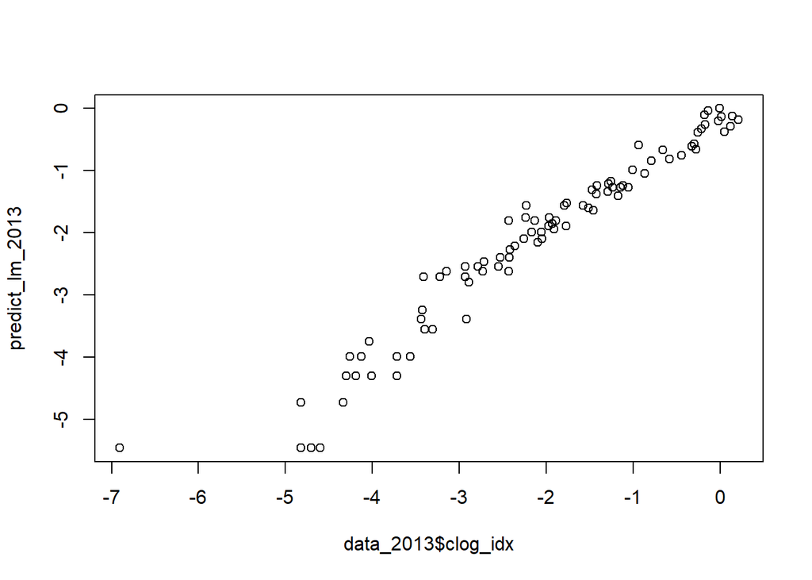

```r
predict_lm_2013 <- predict(lm_2013, data_2013, type = "response")

plot(data_2013$clog_idx, predict_lm_2013)
```

```r
cor(data_2013$clog_idx, predict_lm_2013)^2
```

```
## [1] 0.9489998
```

## 2014

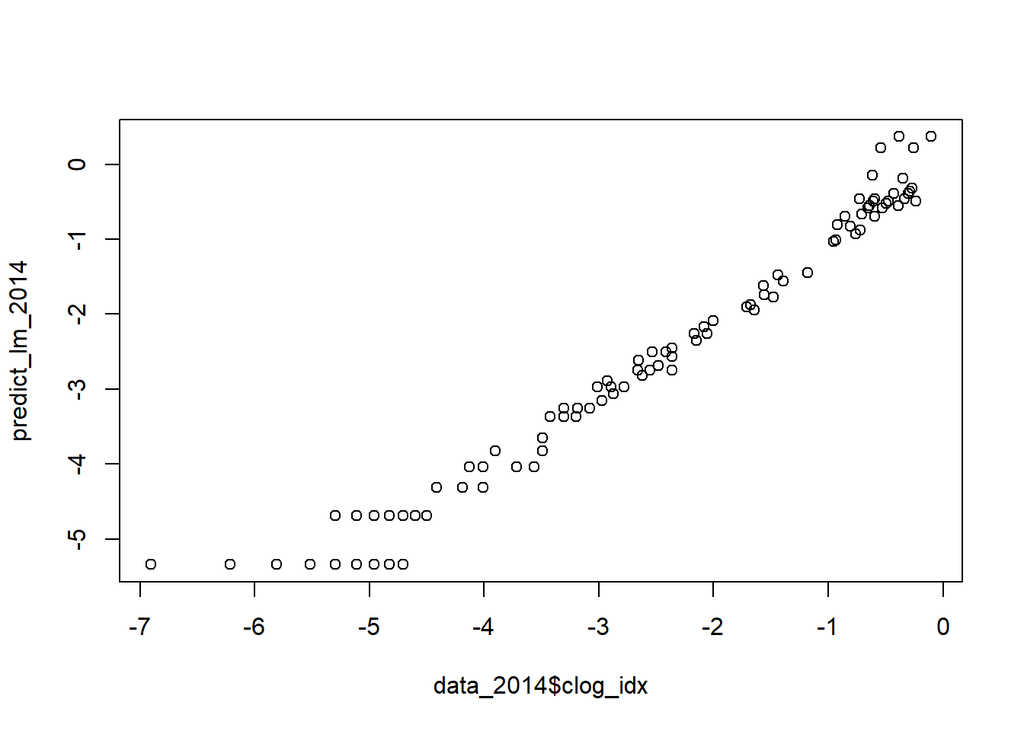

```r
predict_lm_2014 <- predict(lm_2014, data_2014, type = "response")

plot(data_2014$clog_idx, predict_lm_2014)
```

```r
cor(data_2014$clog_idx, predict_lm_2014)^2
```

```
## [1] 0.973559
```

## 2015

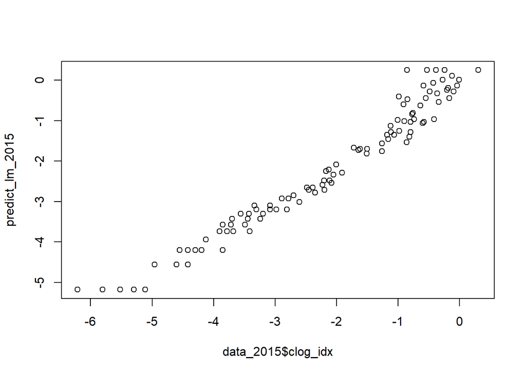

```r
predict_lm_2015 <- predict(lm_2015, data_2015, type = "response")

plot(data_2015$clog_idx, predict_lm_2015)
```

```r
cor(data_2015$clog_idx, predict_lm_2015)^2
```

```
## [1] 0.9646254
```

## 2016

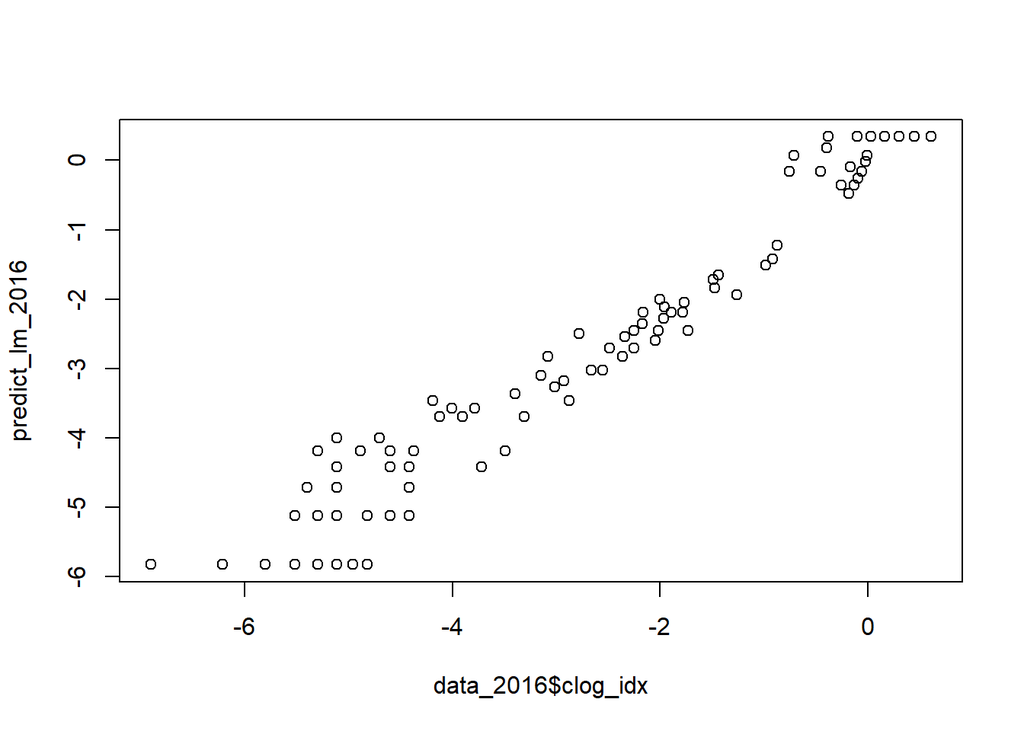

```r
predict_lm_2016 <- predict(lm_2016, data_2016, type = "response")

plot(data_2016$clog_idx, predict_lm_2016)
```

```r
cor(data_2016$clog_idx, predict_lm_2016)^2
```

```
## [1] 0.9469235
```

## 2017

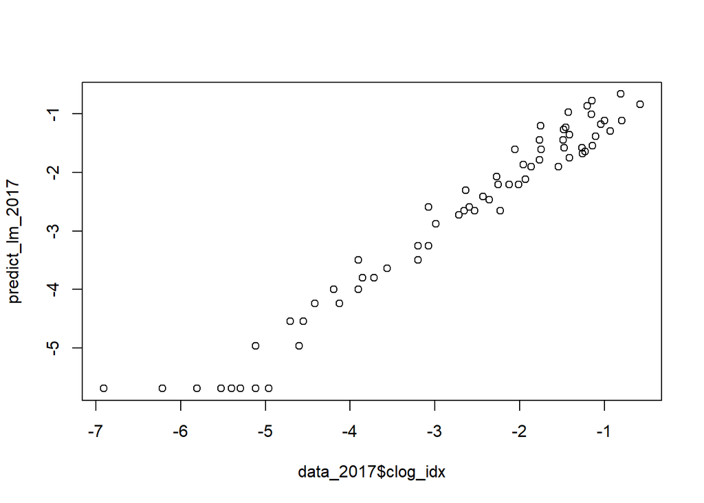

```r
predict_lm_2017 <- predict(lm_2017, data_2017, type = "response")

plot(data_2017$clog_idx, predict_lm_2017)
```

```r
cor(data_2017$clog_idx, predict_lm_2017)^2
```

```
## [1] 0.9566022
```

## 2018

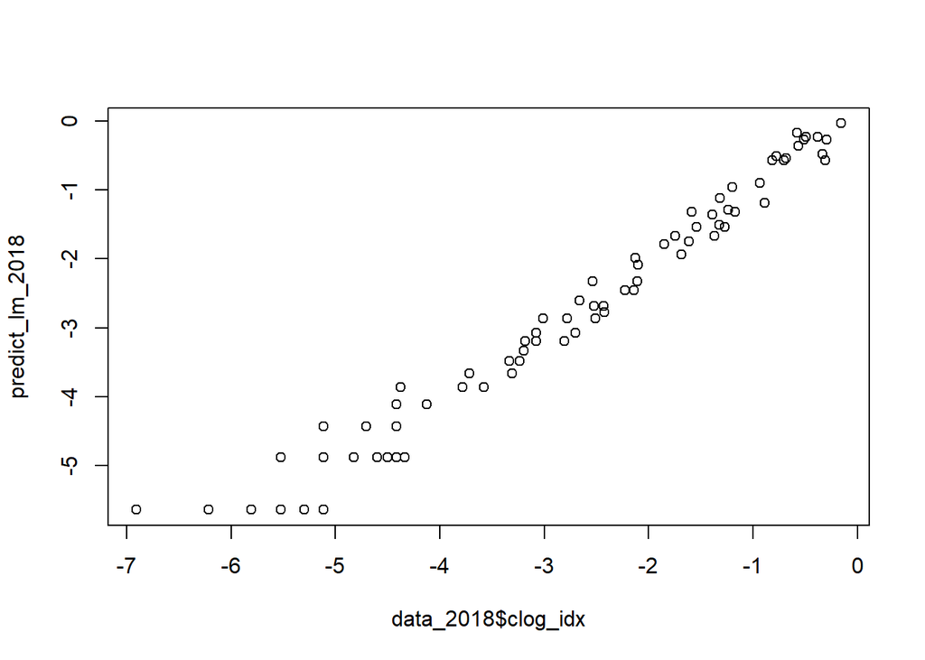

```r
predict_lm_2018 <- predict(lm_2018, data_2018, type = "response")

plot(data_2018$clog_idx, predict_lm_2018)
```

```r
cor(data_2018$clog_idx, predict_lm_2018)^2
```

```
## [1] 0.9667579
```

## 2019

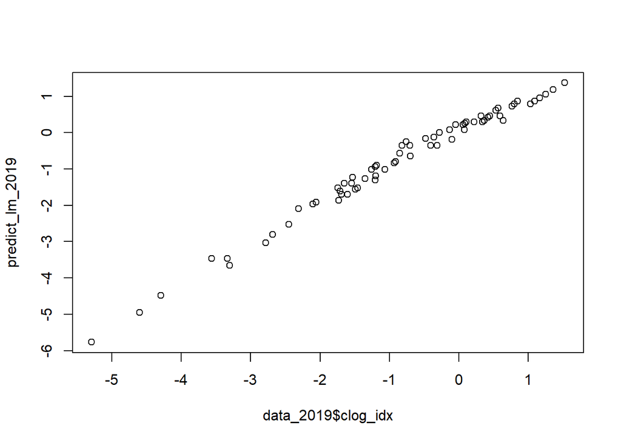

```r
predict_lm_2019 <- predict(lm_2019, data_2019, type = "response")

plot(data_2019$clog_idx, predict_lm_2019)
```

```r
cor(data_2019$clog_idx, predict_lm_2019)^2
```

```
## [1] 0.984205
```

## EPAMIG pooled data

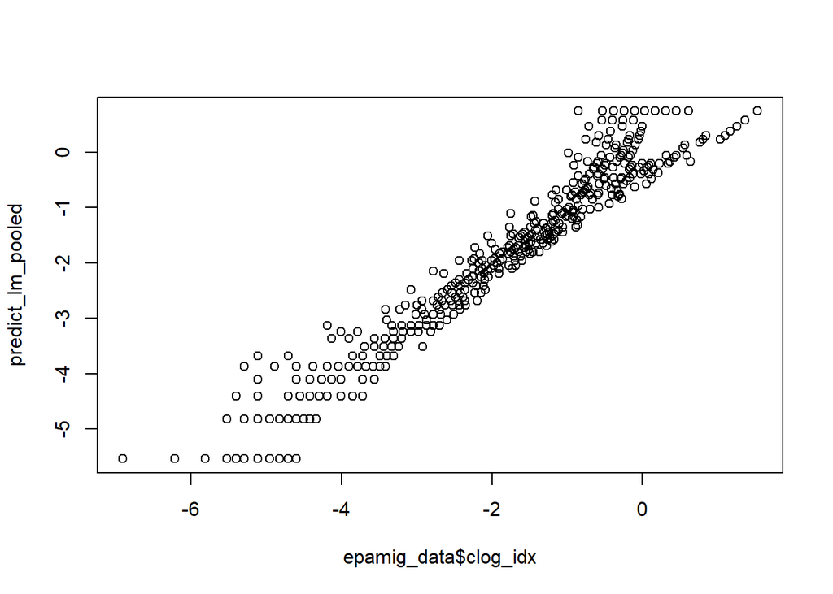

```r
predict_lm_pooled <- predict(lm_pooled, epamig_data, type = "response")

plot(epamig_data$clog_idx, predict_lm_pooled)
```

```r
cor(epamig_data$clog_idx, predict_lm_pooled)^2
```

```
## [1] 0.9508336
```

## UFTs data

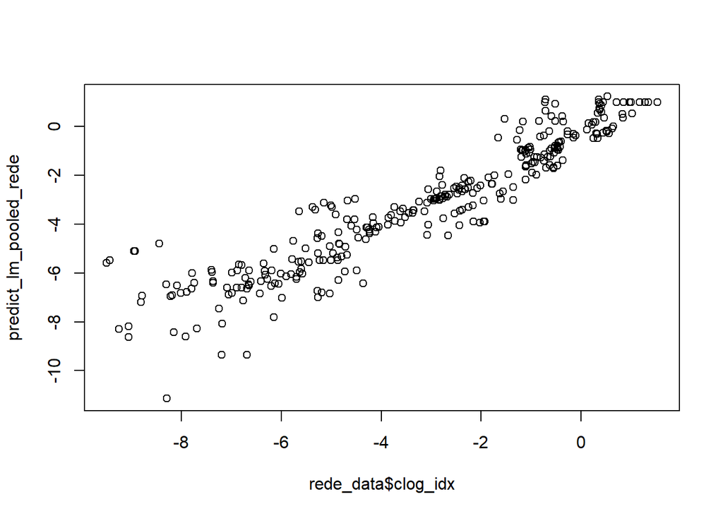

```r
predict_lm_pooled_rede <- predict(lm_pooled_rede, rede_data, type = "response")

plot(rede_data$clog_idx, predict_lm_pooled_rede)
```

```r
cor(rede_data$clog_idx, predict_lm_pooled_rede)^2
```

```
## [1] 0.8786065
```

# Predicitons

Here using the model’s coefficients, we calculate two distinct predictions, the predicted severity (*Ŝ*) and a inverse prediction of the model that is the incidence when severity reaches 10% (*I<sup>S</sup><sub>10</sub>*).

## Extraction of Lm coefficients

First, we using the base functions of R we extract the coefficients (intercept and slope) from each model and we storage them in vectors.

```r
b0_2013 <- lm_2013$coefficients[1]
b1_2013 <- lm_2013$coefficients[2]

b0_2014 <- lm_2014$coefficients[1]
b1_2014 <- lm_2014$coefficients[2]

b0_2015 <- lm_2015$coefficients[1]
b1_2015 <- lm_2015$coefficients[2]

b0_2016 <- lm_2016$coefficients[1]
b1_2016 <- lm_2016$coefficients[2]

b0_2017 <- lm_2017$coefficients[1]
b1_2017 <- lm_2017$coefficients[2]

b0_2018 <- lm_2018$coefficients[1]
b1_2018 <- lm_2018$coefficients[2]

b0_2019 <- lm_2019$coefficients[1]
b1_2019 <- lm_2019$coefficients[2]

b0_pooled <- lm_pooled$coefficients[1]
b1_pooled <- lm_pooled$coefficients[2]

b0_pooled_rede <- lm_pooled_rede$coefficients[1]
b1_pooled_rede <- lm_pooled_rede$coefficients[2]
```

## CLL function

For both predictions were necessary to use the values of *S* or *I* at the *CLL( )* scale, so using the base code of the R, we created a function that gives us any value of severity or incidence (in proportion, 0 to 1) at the *CLL ( )* transformation.

```r
CLL = function(X){
  log(-log(1 - X))
}
```

## Ŝ

In both predictions, we want to visualize the *I<sup>S</sup><sub>10</sub>* and the *Ŝ* at the regular scale, then a back-transformation of the *CLL ( )* was necessary.

It is important to note that the model gives us predicted values of S at the *CLL( )* scale, so *Ŝ* was obtained by the back-transformation of *CLL ( )* that is given by: 1-exp(-exp(CLL(S)))

```r
sev_2013 <- 1 - exp(-exp(b0_2013 + (b1_2013 * CLL(0.2))))

sev_2014 <- 1 - exp(-exp(b0_2014 + (b1_2014 * CLL(0.2))))

sev_2015 <- 1 - exp(-exp(b0_2015 + (b1_2015 * CLL(0.2))))

sev_2016 <- 1 - exp(-exp(b0_2016 + (b1_2016 * CLL(0.2))))

sev_2017 <- 1 - exp(-exp(b0_2017 + (b1_2017 * CLL(0.2))))

sev_2018 <- 1 - exp(-exp(b0_2018 + (b1_2018 * CLL(0.2))))

sev_2019 <- 1 - exp(-exp(b0_2019 + (b1_2019 * CLL(0.2))))

sev_pooled <- 1 - exp(-exp(b0_pooled + (b1_pooled * CLL(0.3))))

sev_pooled_rede <- 1 - exp(-exp(b0_pooled_rede + (b1_pooled_rede * CLL(0.3))))
```

## I<sup>S</sup><sub>10</sub>

The I<sup>S</sup><sub>10</sub> is an inverse prediction of the model that we developed, and as for *S* the values predicted for the function are in the *CLL( )* scale, then again the back-transformation of *CLL ( )* was necessary.

```r
# complementary log-log transformation function

idx10 <- CLL(0.1)

inc_10_2013 <- 1 - exp( -exp((idx10 - b0_2013)/b1_2013))

inc_10_2014 <- 1 - exp( -exp((idx10 - b0_2014)/b1_2014))

inc_10_2015 <- 1 - exp( -exp((idx10 - b0_2015)/b1_2015))

inc_10_2016 <- 1 - exp( -exp((idx10 - b0_2016)/b1_2016))

inc_10_2017 <- 1 - exp( -exp((idx10 - b0_2017)/b1_2017))

inc_10_2018 <- 1 - exp( -exp((idx10 - b0_2018)/b1_2018))

inc_10_2019 <- 1 - exp( -exp((idx10 - b0_2019)/b1_2019))

inc_10_pooled <- 1 - exp( -exp((idx10 - b0_pooled)/b1_pooled))

inc_10_pooled_rede <- 1 - exp( -exp((idx10 - b0_pooled_rede)/b1_pooled_rede))
```

# Graphics

All the graphics were created using the `ggplot2` package, and the assembly of the graphics together was made using the `patchwork` package.

We create graphics for each year of the EPAMIG data and for both pooled data (EPAMIG and UFTs).

## Boxplot EPAMIG

```r
box01 <- epamig_data %>%
  ggplot(aes(as.factor(year),(inc/100)))+
  # geom_jitter(width = 0.2,
              # size = 1.3,
              # alpha = 0.3)+
  geom_boxplot(alpha = 0.2,
               outlier.shape = NA,
               size = 0.9,
               width = 0.7)+
  scale_color_colorblind()+
  scale_fill_colorblind()+
  theme_half_open()+
  xlab("EPAMIG")+
  ylab("Incidence")+
  theme(legend.position = "top")+
  labs(color = "Cultivar", fill = "Cultivar")


box02 <- epamig_data %>%
  ggplot(aes(as.factor(year),(idx/100)))+
  # geom_jitter(width = 0.2,
              # size = 1.3,
              # alpha = 0.3)+
  geom_boxplot(alpha = 0.2,
               outlier.shape = NA,
               size = 0.9,
               width = 0.7)+
  scale_color_colorblind()+
  scale_fill_colorblind()+
  theme_half_open()+
  xlab("EPAMIG")+
  ylab("Severity")+
  theme(legend.position = "top")+
  labs(color = "Cultivar",
       fill = "Cultivar")
```

## Boxplot UFTs

```r
box03 <- rede_data %>%
  mutate(graf = "UFTs") %>%
  ggplot(aes(graf, (inc_rede/100))) +
  geom_boxplot(alpha = 0.2,
               outlier.shape = NA,
               size = 0.9,
               width = 0.3)+
  scale_color_colorblind()+
  scale_fill_colorblind()+
  theme_half_open()+
  xlab("UFTs")+
  ylab("")+
  theme(legend.position = "top",
        axis.text.x = element_blank(),
        axis.ticks.y = element_blank(),
        axis.text.y = element_blank(),
        panel.grid = element_blank())

box04 <- rede_data %>%
  mutate(graf = "UFTs") %>%
  ggplot(aes(graf, (idx_rede/100))) +
  geom_boxplot(alpha = 0.2,
               outlier.shape = NA,
               size = 0.9,
               width = 0.3)+
  scale_color_colorblind()+
  scale_fill_colorblind()+
  theme_half_open()+
  xlab("UFTs")+
  ylab("")+
  theme(legend.position = "top",
        axis.text.x = element_blank(),
        axis.ticks.y = element_blank(),
        axis.text.y = element_blank(),
        panel.grid = element_blank())
```

## Histograms

```r
hist01 <- epamig_data %>%
  ggplot(aes(inc))+
  geom_histogram(color = "black",
                 fill = "black",
                 alpha = 0.1)+
  geom_vline(xintercept = 35.70,
             size = 1.2,
             linetype = 2)+
  ylab("")+
  xlab("I (%)")+
  theme_minimal_hgrid()
```

```r
hist02 <- epamig_data %>%
  ggplot(aes(dhs))+
  geom_histogram(color = "black",
                 fill = "black",
                 alpha = 0.1)+
  geom_vline(xintercept = 53.04,
             size = 1.2,
             linetype = 2)+
  ylab("")+
  xlab("DHS (%)")+
  theme_minimal_hgrid()
```

```r
hist03 <- epamig_data %>%
  ggplot(aes(idx))+
  geom_histogram(color = "black",
                 fill = "black",
                 alpha = 0.1)+
  geom_vline(xintercept = 22.60,
             size = 1.2,
             linetype = 2)+
  ylab("")+
  xlab("S (%)")+
  theme_minimal_hgrid()
```

```r
hist01_rede <- rede_data %>%
  ggplot(aes(inc_rede))+
  geom_histogram(color = "black",
                 fill = "black",
                 alpha = 0.1)+
  geom_vline(xintercept = 41.85,
             size = 1.2,
             linetype = 2)+
  ylab("")+
  xlab("I (%)")+
  theme_minimal_hgrid()
```

```r
hist02_rede <- rede_data %>%
  ggplot(aes(sev_mean))+
  geom_histogram(color = "black",
                 fill = "black",
                 alpha = 0.1)+
  geom_vline(xintercept = 31.75,
             size = 1.2,
             linetype = 2)+
  ylab("")+
  xlab("DHS (%)")+
  theme_minimal_hgrid()
```

```r
hist03_rede <- rede_data %>%
  ggplot(aes(idx_rede))+
  geom_histogram(color = "black",
                 fill = "black",
                 alpha = 0.1)+
  geom_vline(xintercept = 22.9,
             size = 1.2,
             linetype = 2)+
  ylab("")+
  xlab("S (%)")+
  theme_minimal_hgrid()
```

## Patchwork of histograms and boxplots

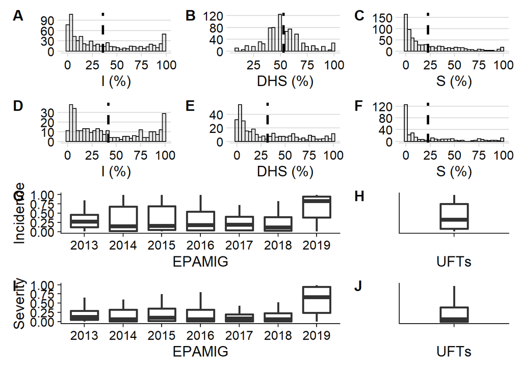

```r
layout <- "
AABBCC
DDEEFF
GGGGHH
IIIIJJ
"
hist01 + hist02 + hist03 + hist01_rede + hist02_rede + hist03_rede + box01 + box03 + box02 + box04 +
  plot_layout(design = layout)+
  plot_annotation(tag_levels = 'A')
```

```r
ggsave("figures/boxplot_histo.png", width = 6, height = 9)
```

## Regression graphics (CLL) and back-transformad data

### 2013 CLL

```r
GCLL_2013 <- data_2013 %>%
  ggplot(aes(clog_inc, clog_idx))+
  geom_point(size = 2,
             color = "black",
             alpha = 0.5,
             width = 0.5)+
  geom_line(data = data_2013, aes(clog_inc, fit.fit),
            size = 1.2)+
  geom_line(data = data_2013, aes(clog_inc, fit.lwr),
            linetype = 2,
            size = 0.5)+
  geom_line(data = data_2013, aes(clog_inc, fit.upr),
            linetype = 2,
            size = 0.5)+
  xlim(-6,1)+
  ylim(-6,1)+
  labs(title = 2013)+
  ylab("CLL Severity ")+
  xlab("CLL Incidence")+
  coord_fixed()+
  # ylim(-6, 2)+
  theme_half_open()
```

### 2013 Back-transformation

```r
GB_2013 <- data_2013 %>%
  ggplot(aes((1 - exp(-exp(clog_inc))), (1 - exp(-exp(clog_idx)))))+
  geom_point(color = "black",
             size = 2,
             alpha = 0.5,
             width = 0.5)+
  geom_line(data = data_2013, aes((1 - exp(-exp(clog_inc))), (1 - exp(-exp(fit.fit)))),
            size = 1.5)+
  geom_line(data = data_2013, aes((1 - exp(-exp(clog_inc))), (1 - exp(-exp(fit.lwr)))),
            size = 0.5,
            linetype = 2)+
  geom_line(data = data_2013, aes((1 - exp(-exp(clog_inc))), (1 - exp(-exp(fit.upr)))),
            size = 0.5,
            linetype = 2)+
  ylab("Severity")+
  xlab("Incidence")+
  xlim(0,1)+
  ylim(0,1)+
  labs(title = 2013)+
  coord_fixed()+
  theme_half_open()
```

### 2014 CLL

```r
GCLL_2014 <- data_2014 %>%
  ggplot(aes(clog_inc, clog_idx))+
  geom_point(size = 2,
             color = "black",
             alpha = 0.5,
             width = 0.5)+
  geom_line(data = data_2014, aes(clog_inc, fit.fit),
            size = 1.2)+
  geom_line(data = data_2014, aes(clog_inc, fit.lwr),
            linetype = 2,
            size = 0.5)+
  geom_line(data = data_2014, aes(clog_inc, fit.upr),
            linetype = 2,
            size = 0.5)+
  xlim(-6,1)+
  ylim(-6,1)+
  labs(title = 2014)+
  ylab("CLL Severity")+
  xlab("CLL Incidence")+
  coord_fixed()+
  # ylim(-6, 2)+
  theme_half_open()
```

### 2014 Back-transformed data

```r
GB_2014 <- data_2014 %>%
  ggplot(aes((1 - exp(-exp(clog_inc))), (1 - exp(-exp(clog_idx)))))+
  geom_point(color = "black",
             size = 2,
             alpha = 0.5,
             width = 0.5)+
  geom_line(data = data_2014, aes((1 - exp(-exp(clog_inc))), (1 - exp(-exp(fit.fit)))),
            size = 1.5)+
  geom_line(data = data_2014, aes((1 - exp(-exp(clog_inc))), (1 - exp(-exp(fit.lwr)))),
            size = 0.5,
            linetype = 2)+
  geom_line(data = data_2014, aes((1 - exp(-exp(clog_inc))), (1 - exp(-exp(fit.upr)))),
            size = 0.5,
            linetype = 2)+
  ylab("Severity")+
  xlab("Incidence")+
  xlim(0,1)+
  ylim(0,1)+
  labs(title = 2014)+
  coord_fixed()+
  theme_half_open()
```

### 2015 CLL

```r
GCLL_2015 <- data_2015 %>%
  ggplot(aes(clog_inc, clog_idx))+
  geom_point(size = 2,
             color = "black",
             alpha = 0.5,
             width = 0.5)+
  geom_line(data = data_2015, aes(clog_inc, fit.fit),
            size = 1.2)+
  geom_line(data = data_2015, aes(clog_inc, fit.lwr),
            linetype = 2,
            size = 0.5)+
  geom_line(data = data_2015, aes(clog_inc, fit.upr),
            linetype = 2,
            size = 0.5)+
  xlim(-6,1)+
  ylim(-6,1)+
  labs(title = 2015)+
  ylab("CLL Severity")+
  xlab("CLL Incidence")+
  coord_fixed()+
  # ylim(-6, 2)+
  theme_half_open()
```

### 2015 Back-trasformed

```r
# seq01 <- seq(-4.60, cem, by = 0.1)

# incidx_2015 <- (b0_2015 + (b1_2015*seq01))

# graf_2015 <- data.frame(incidx_2015)



GB_2015 <- data_2015 %>%
  ggplot(aes((1 - exp(-exp(clog_inc))), (1 - exp(-exp(clog_idx)))))+
  geom_point(color = "black",
             size = 2,
             alpha = 0.5,
             width = 0.5)+
  geom_line(data = data_2015, aes((1 - exp(-exp(clog_inc))), (1 - exp(-exp(fit.fit)))),
            size = 1.5)+
  geom_line(data = data_2015, aes((1 - exp(-exp(clog_inc))), (1 - exp(-exp(fit.lwr)))),
            size = 0.5,
            linetype = 2)+
  geom_line(data = data_2015, aes((1 - exp(-exp(clog_inc))), (1 - exp(-exp(fit.upr)))),
            size = 0.5,
            linetype = 2)+
  ylab("Severity")+
  xlab("Incidence")+
  xlim(0,1)+
  ylim(0,1)+
  labs(title = 2015)+
  coord_fixed()+
  theme_half_open()
```

### 2016 CLL

```r
GCLL_2016 <- data_2016 %>%
  ggplot(aes(clog_inc, clog_idx))+
  geom_point(size = 2,
             color = "black",
             alpha = 0.5,
             width = 0.5)+
  geom_line(data = data_2016, aes(clog_inc, fit.fit),
            size = 1.2)+
  geom_line(data = data_2016, aes(clog_inc, fit.lwr),
            linetype = 2,
            size = 0.5)+
  geom_line(data = data_2016, aes(clog_inc, fit.upr),
            linetype = 2,
            size = 0.5)+
  xlim(-6,1)+
  ylim(-6,1)+
  labs(title = 2016)+
  ylab("CLL Severity")+
  xlab("CLL Incidence")+
  coord_fixed()+
  # ylim(-6, 2)+
  theme_half_open()
```

### 2016 Back-transformed

```r
# seq01 <- seq(-4.60, cem, by = 0.1)

# incidx_2016 <- (b0_2016 + (b1_2016*seq01))

# graf_2016 <- data.frame(incidx_2016)



GB_2016 <- data_2016 %>%
  ggplot(aes((1 - exp(-exp(clog_inc))), (1 - exp(-exp(clog_idx)))))+
  geom_point(color = "black",
             size = 2,
             alpha = 0.5,
             width = 0.5)+
  geom_line(data = data_2016, aes((1 - exp(-exp(clog_inc))), (1 - exp(-exp(fit.fit)))),
            size = 1.5)+
  geom_line(data = data_2016, aes((1 - exp(-exp(clog_inc))), (1 - exp(-exp(fit.lwr)))),
            size = 0.5,
            linetype = 2)+
  geom_line(data = data_2016, aes((1 - exp(-exp(clog_inc))), (1 - exp(-exp(fit.upr)))),
            size = 0.5,
            linetype = 2)+
  ylab("Severity")+
  xlab("Incidence")+
  xlim(0,1)+
  ylim(0,1)+
  labs(title = 2016)+
  coord_fixed()+
  theme_half_open()
```

### 2017 CLL

```r
GCLL_2017 <- data_2017 %>%
  ggplot(aes(clog_inc, clog_idx))+
  geom_point(size = 2,
             color = "black",
             alpha = 0.5,
             width = 0.5)+
  geom_line(data = data_2017, aes(clog_inc, fit.fit),
            size = 1.2)+
  geom_line(data = data_2017, aes(clog_inc, fit.lwr),
            linetype = 2,
            size = 0.5)+
  geom_line(data = data_2017, aes(clog_inc, fit.upr),
            linetype = 2,
            size = 0.5)+
  xlim(-6,1)+
  ylim(-6,1)+
  labs(title = 2017)+
  ylab("CLL Severity")+
  xlab("CLL Incidence")+
  coord_fixed()+
  # ylim(-6, 2)+
  theme_half_open()
```

### 2017 back-transformed

```r
# seq01 <- seq(-4.60, cem, by = 0.1)

# incidx_2017 <- (b0_2017 + (b1_2017*seq01))

# graf_2017 <- data.frame(incidx_2017)



GB_2017 <- data_2017 %>%
  ggplot(aes((1 - exp(-exp(clog_inc))), (1 - exp(-exp(clog_idx)))))+
  geom_point(color = "black",
             size = 2,
             alpha = 0.5,
             width = 0.5)+
  geom_line(data = data_2017, aes((1 - exp(-exp(clog_inc))), (1 - exp(-exp(fit.fit)))),
            size = 1.5)+
  geom_line(data = data_2017, aes((1 - exp(-exp(clog_inc))), (1 - exp(-exp(fit.lwr)))),
            size = 0.5,
            linetype = 2)+
  geom_line(data = data_2017, aes((1 - exp(-exp(clog_inc))), (1 - exp(-exp(fit.upr)))),
            size = 0.5,
            linetype = 2)+
  ylab("Severity")+
  xlab("Incidence")+
  xlim(0,1)+
  ylim(0,1)+
  labs(title = 2017)+
  coord_fixed()+
  theme_half_open()
```

### 2018 CLL

```r
GCLL_2018 <- data_2018 %>%
  ggplot(aes(clog_inc, clog_idx))+
  geom_point(size = 2,
             color = "black",
             alpha = 0.5,
             width = 0.5)+
  geom_line(data = data_2018, aes(clog_inc, fit.fit),
            size = 1.2)+
  geom_line(data = data_2018, aes(clog_inc, fit.lwr),
            linetype = 2,
            size = 0.5)+
  geom_line(data = data_2018, aes(clog_inc, fit.upr),
            linetype = 2,
            size = 0.5)+
  xlim(-6,1)+
  ylim(-6,1)+
  labs(title = 2018)+
  ylab("CLL Severity")+
  xlab("CLL Incidence")+
  coord_fixed()+
  # ylim(-6, 2)+
  theme_half_open()
```

### 2018 Back-transformed

```r
# seq01 <- seq(-4.60, cem, by = 0.1)

# incidx_2018 <- (b0_2018 + (b1_2018*seq01))

# graf_2018 <- data.frame(incidx_2018)


GB_2018 = data_2018 %>%
  ggplot(aes((1 - exp(-exp(clog_inc))), (1 - exp(-exp(clog_idx)))))+
  geom_point(color = "black",
             size = 2,
             alpha = 0.5,
             width = 0.5)+
  geom_line(data = data_2018, aes((1 - exp(-exp(clog_inc))), (1 - exp(-exp(fit.fit)))),
            size = 1.5)+
  geom_line(data = data_2018, aes((1 - exp(-exp(clog_inc))), (1 - exp(-exp(fit.lwr)))),
            size = 0.5,
            linetype = 2)+
  geom_line(data = data_2018, aes((1 - exp(-exp(clog_inc))), (1 - exp(-exp(fit.upr)))),
            size = 0.5,
            linetype = 2)+
  ylab("Severity")+
  xlab("Incidence")+
  xlim(0,1)+
  ylim(0,1)+
  labs(title = 2018)+
  coord_fixed()+
  theme_half_open()
```

### 2019 CLL

```r
GCLL_2019 = data_2019 %>%
  ggplot(aes(clog_inc, clog_idx))+
  geom_point(size = 2,
             color = "black",
             alpha = 0.5,
             width = 0.5)+
  geom_line(data = data_2019, aes(clog_inc, fit.fit),
            size = 1.2)+
  geom_line(data = data_2019, aes(clog_inc, fit.lwr),
            linetype = 2,
            size = 0.5)+
  geom_line(data = data_2019, aes(clog_inc, fit.upr),
            linetype = 2,
            size = 0.5)+
  xlim(-6,1)+
  ylim(-6,1)+
  labs(title = 2019)+
  ylab("CLL Severity")+
  xlab("CLL Incidence")+
  coord_fixed()+
  # ylim(-6, 2)+
  theme_half_open()
```

### 2019 Back-transformed

```r
# seq01 <- seq(-4.60, cem, by = 0.1)

# incidx_2019 <- (b0_2019 + (b1_2019*seq01))

# graf_2019 <- data.frame(incidx_2019)


GB_2019 = data_2019 %>%
  ggplot(aes((1 - exp(-exp(clog_inc))), (1 - exp(-exp(clog_idx)))))+
  geom_point(color = "black",
             size = 2,
             alpha = 0.5,
             width = 0.5)+
  geom_line(data = data_2019, aes((1 - exp(-exp(clog_inc))), (1 - exp(-exp(fit.fit)))),
            size = 1.5)+
  geom_line(data = data_2019, aes((1 - exp(-exp(clog_inc))), (1 - exp(-exp(fit.lwr)))),
            size = 0.5,
            linetype = 2)+
  geom_line(data = data_2019, aes((1 - exp(-exp(clog_inc))), (1 - exp(-exp(fit.upr)))),
            size = 0.5,
            linetype = 2)+
  ylab("Severity")+
  xlab("Incidence")+
  xlim(0,1)+
  ylim(0,1)+
  labs(title = 2019)+
  coord_fixed()+
  theme_half_open()
```

### Pooled CLL

```r
GCLL_pool <- epamig_data %>%
  ggplot(aes(clog_inc, clog_idx))+
  geom_point(size = 2,
             color = "black",
             alpha = 0.1,
             width = 0.5)+
  geom_line(data = epamig_data, aes(clog_inc, fit.fit),
            size = 1.2)+
  geom_line(data = epamig_data, aes(clog_inc, fit.lwr),
            linetype = 2,
            size = 0.5)+
  geom_line(data = epamig_data, aes(clog_inc, fit.upr),
            linetype = 2,
            size = 0.5)+
  xlim(-6,1)+
  ylim(-6,1)+
  labs(title = "EPAMIG")+
  ylab("CLL Severity")+
  xlab("CLL Incidence")+
  coord_fixed()+
  # ylim(-6, 2)+
  theme_half_open()
```

### Pooled Back-transformed

```r
# seq01 <- seq(-4.60, cem, by = 0.1)

# incidx_pooled <- (b0_pooled + (b1_pooled*seq01))

# graf_pooled <- data.frame(incidx_pooled)



GB_pool <- epamig_data %>%
  ggplot(aes((1 - exp(-exp(clog_inc))), (1 - exp(-exp(clog_idx)))))+
  geom_point(color = "black",
             size = 2,
             alpha = 0.1,
             width = 0.5)+
  geom_line(data = epamig_data, aes((1 - exp(-exp(clog_inc))), (1 - exp(-exp(fit.fit)))),
            size = 1.5)+
  geom_line(data = epamig_data, aes((1 - exp(-exp(clog_inc))), (1 - exp(-exp(fit.lwr)))),
            size = 0.5,
            linetype = 2)+
  geom_line(data = epamig_data, aes((1 - exp(-exp(clog_inc))), (1 - exp(-exp(fit.upr)))),
            size = 0.5,
            linetype = 2)+
  ylab("Severity")+
  xlab("Incidence")+
  xlim(0,1)+
  ylim(0,1)+
  labs(title = "EPAMIG")+
  coord_fixed()+
  theme_half_open()
```

### Pooled rede

```r
GCLL_pool_rede <- rede_data %>%
  ggplot(aes(clog_inc, clog_idx))+
  geom_point(size = 2,
             color = "black",
             alpha = 0.1,
             width = 0.5)+
  geom_line(data = rede_data, aes(clog_inc, fit.fit),
            size = 1.2)+
  geom_line(data = rede_data, aes(clog_inc, fit.lwr),
            linetype = 2,
            size = 0.5)+
  geom_line(data = rede_data, aes(clog_inc, fit.upr),
            linetype = 2,
            size = 0.5)+
  xlim(-6,1)+
  ylim(-6,1)+
  labs(title = "UFTs")+
  ylab("CLL Severity")+
  xlab("CLL Incidence")+
  coord_fixed()+
  # ylim(-6, 2)+
  theme_half_open()
```

### Pooled Rede Back-transformed

```r
# seq01 <- seq(-4.60, cem, by = 0.1)

# incidx_pooled <- (b0_pooled + (b1_pooled*seq01))

# graf_pooled <- data.frame(incidx_pooled)



GB_pool_rede <- rede_data %>%
  ggplot(aes((1 - exp(-exp(clog_inc))), (1 - exp(-exp(clog_idx)))))+
  geom_point(color = "black",
             size = 2,
             alpha = 0.1,
             width = 0.5)+
  geom_line(data = rede_data, aes((1 - exp(-exp(clog_inc))), (1 - exp(-exp(fit.fit)))),
            size = 1.5)+
  geom_line(data = rede_data, aes((1 - exp(-exp(clog_inc))), (1 - exp(-exp(fit.lwr)))),
            size = 0.5,
            linetype = 2)+
  geom_line(data = rede_data, aes((1 - exp(-exp(clog_inc))), (1 - exp(-exp(fit.upr)))),
            size = 0.5,
            linetype = 2)+
  ylab("Severity")+
  xlab("Incidence")+
  xlim(0,1)+
  ylim(0,1)+
  labs(title = "UFTs")+
  coord_fixed()+
  theme_half_open()
```

[figure not shown]

```r
(GCLL_2013 + GCLL_2014 + GCLL_2015 + GCLL_2016 + GCLL_2017 + GCLL_2018 + GCLL_2019)+
  plot_layout(ncol = 2)
```

```r
ggsave("figures/CLLplots02.png", width = 13, height = 15)
```

### Back-transformed

[figure not shown]

```r
(GB_2013 + GB_2014 + GB_2015 + GB_2016 + GB_2017 + GB_2018 + GB_2019)+
  plot_layout(ncol = 2)
```

```r
ggsave("figures/BTplots02.png", width = 13, height = 15)
```

### Pooleds

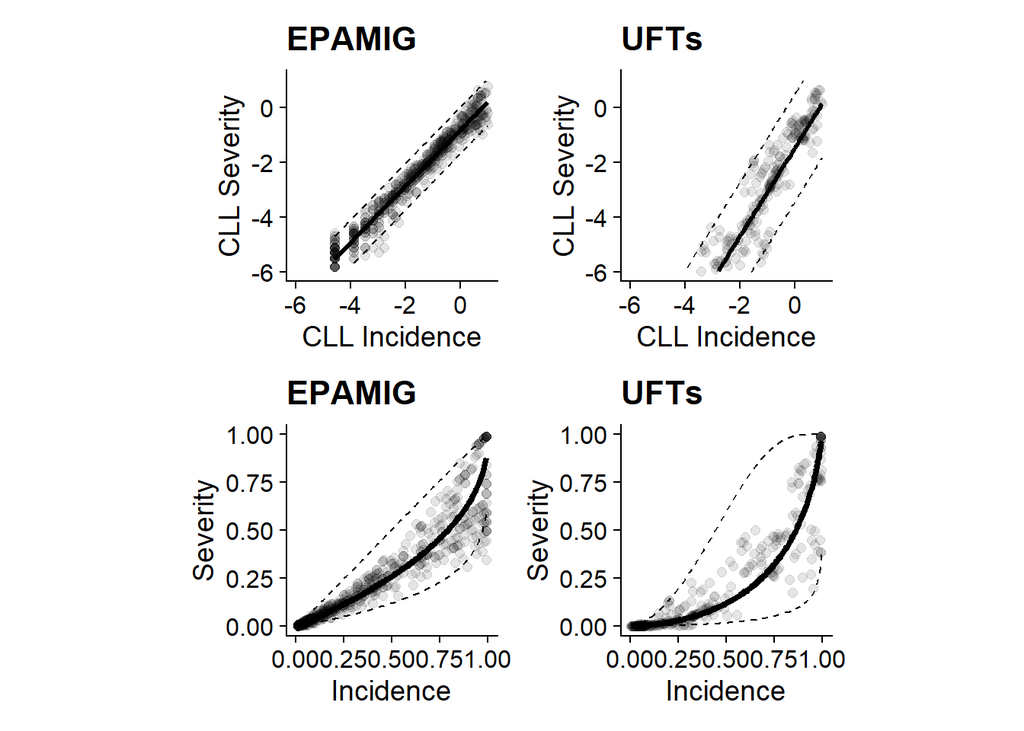

```r
(GCLL_pool + GCLL_pool_rede +  GB_pool +  GB_pool_rede)+
  plot_layout(ncol = 2)
```

```r
ggsave("figures/Pooleds.png", width = 7, height = 7)
```